# Lecture 4

Optimization: stochastic methods

2024-11-05

## Optimization - Determinisitc vs. stochastic

The algorithms discussed before have been **deterministic**. Given the same input (data, objective function, initial values if non-linear) algorithms produce the same output:

- Linear least squares (normal equations)
- Non-linear one-dimensional (Golden section search)
- Non-linear least squares (Gauss Newton)

We will now look at **stochastic** (or probabilistic) methods, i.e. methods that do not always produce the same output, since they involve randomization.

## MCMC - Markov chain Monte Carlo methods

The underlying principle is that of MCMC

**Monte Carlo algorithms:**

- Include randomization to compute results
- Results are not deterministic, running time is (compare Las Vegas algorithms)
- More samples typically lead to better results
- Example: Approximate $\pi$ by counting the portion of $(U(-1,1), U(-1,1))$ distributed random points that lie inside the unit circle.

## MCMC - Markov chain Monte Carlo methods

**Monte Carlo algorithms:**

Example: Approximate $\pi$ by counting the portion of $(U(-1,1), U(-1,1))$ distributed random points that lie inside the unit circle ? Let´s try this out.

## MCMC - Markov chain Monte Carlo methods

**Monte Carlo algorithms:**

Example: Approximate $\pi$ by counting the portion of $(U(-1,1), U(-1,1))$ distributed random points that lie inside the unit circle ? Let´s try this out.

**Why does that work?**

$\text{Area of the square} = \text{side} \times \text{side} = 2 \times 2 = 4$

$\text{Area of the circle} = \pi \times r^2 = \pi \times (1)^2 = \pi \times 1 = \pi$

$\text{proportion_square_circle} = \frac{\text{Area of the circle}}{\text{Area of the square}} = \frac{\pi}{4}$

$\pi = \text{proportion_square_circle} \times 4$

## MCMC - Markov chain Monte Carlo methods

**Monte Carlo algorithms:**

Example: Approximate $\pi$ by counting the portion of $(U(-1,1), U(-1,1))$ distributed random points that lie inside the unit circle ? Let´s try this out.

**Why does that work?**

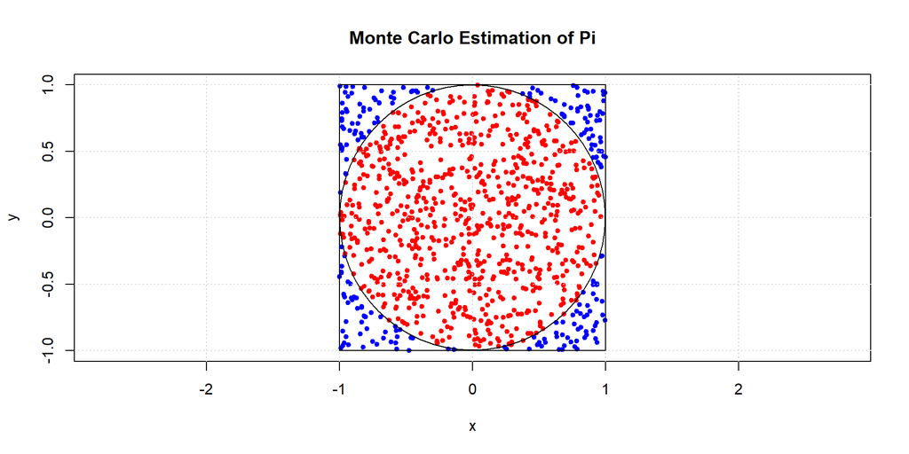

## MCMC - Markov chain Monte Carlo methods

**Monte Carlo algorithms:**

Example: Approximate $\pi$ by counting the portion of $(U(-1,1), U(-1,1))$ distributed random points that lie inside the unit circle ? Let´s try this out.

**How does that work?**

Function in R:

```r
set.seed(321)  # Set seed for reproducibility
monte_carlo_pi <- function(n_samples){
  # Generate random points
  x <- runif(n_samples, min=-1,max = 1)  # Uniformly distributed random numbers for x-coordinate
  y <- runif(n_samples,min=-1,max = 1)  # Uniformly distributed random numbers for y-coordinate
  # Calculate the number of points that lie inside the circle
  inside_circle <- sum(x^2 + y^2 <= 1^2)

  # Estimate Pi as shown in previous slide
  pi_estimate <- 4 * (inside_circle / n_samples)
  # Print the estimate and difference to actual Pi
  print(pi_estimate)
  print(pi_estimate-pi)
}
```

Run with 1000 samples:

```
[1] 3.168
[1] 0.02640735
```

Run with 100000 samples:

```
[1] 3.14752
[1] 0.005927346
```

## MCMC - Markov chain Monte Carlo methods

The underlying principle is that of MCMC

**Markov chains:**

- a one-dimensional sequence of random variables (stochastic process) where the next value depends only on the current value but not on past values
- $P(x_i | x_{i-1}, x_{i-2}, x_{i-3}, ...) = P(x_i | x_{i-1})$
- are autocorrelated
- Examples: Random walk, AR(1)

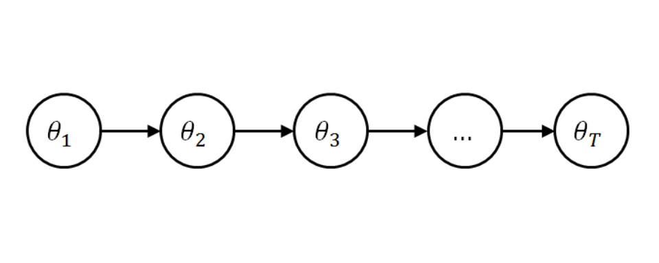

## MCMC - Markov chain Monte Carlo methods

**Idea of MCMC for optimization:**

- Generate a Markov chain by randomly proposing new parameter values based on the current values
- Compute how likely proposed parameters are compared to current values
- Based on that, decide on accepting the proposal value or not

In the end, this chain converges to the stationary distribution of the parameters.

## Metropolis-Hastings

Why would one want probabilistic search?

- global: unlikely areas are searched too (with small probability)
- a probability distribution is richer than a point estimate:
  - Gauss-Newton provides an estimate $\hat\theta$ of $\theta$, given data $y$. What about the estimation error $\hat\theta - \theta$? Second-order derivatives give approximations to standard errors, but not the full distribution.

We explain the simplified version, the Metropolis algorithm

## Metropolis algorithm

Given a point in parameter space $\theta$, say $x_t = (\theta_{1,t},...,\theta_{p,t})$ we evaluate whether another point, $x'$ is a reasonable alternative. If accepted, we set $x_{t+1}\leftarrow x'$; if not we keep $x_t$ and set $x_{t+1}\leftarrow x_t$.

- if $P(x') > P(x_t)$, we accept $x'$ and set $x_{t+1}=x'$
- if $P(x') < P(x_t)$, then
  - we draw $U$, a random uniform value from $[0,1]$, and
  - accept $x'$ if $U < \frac{P(x')}{P(x_t)}$

## Metropolis algorithm

Often, $x'$ is drawn from some normal distribution centered around $x_t$: $N(x_t,\sigma^2 I)$. Suppose we accept it always, then
$$x_{t+1}=x_t + e_t$$
with $e_t \sim N(0,\sigma^2 I)$. Looks familiar?

## Metropolis algorithm

Two steps in the algorithm involve randomness:

- The proposal density (distribution of jumps), which is often $\theta' \sim \mathcal{N}(\theta_t, \sigma I)$, where $\sigma$ is an important tuning parameter
- The acceptance of worse proposals which depends on the likelihood function of the parameters (see later slides)

Let´s look at some examples with different acceptance rates. These are for fitting the three parameters of the periodic model from earlier lectures.

## Little mixing (too low acceptance rate):

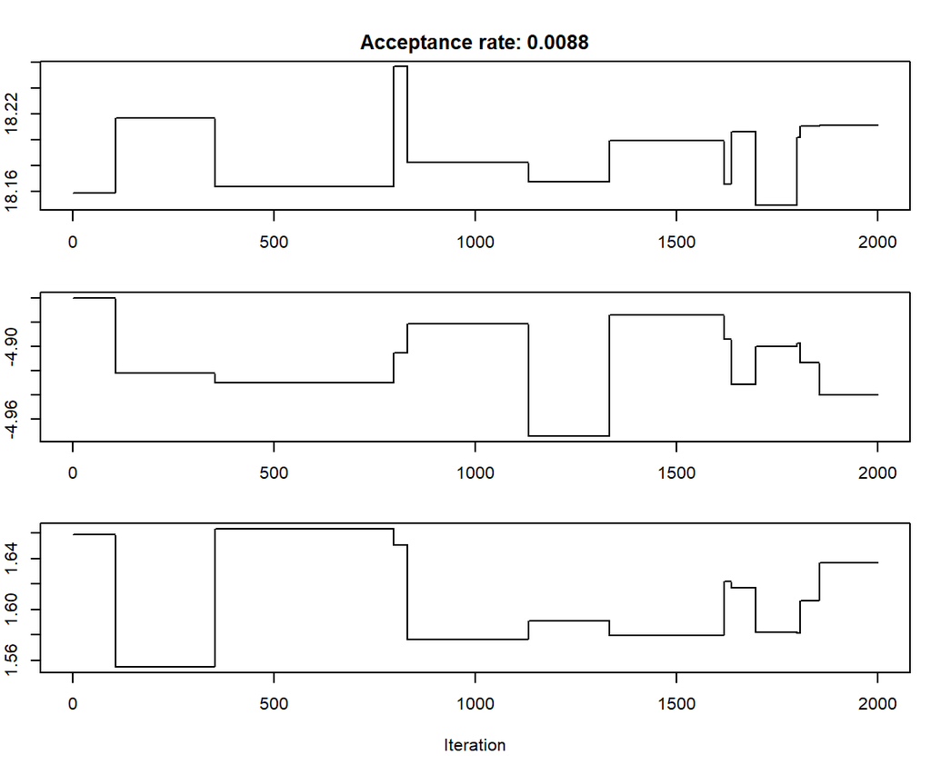

## Better mixing:

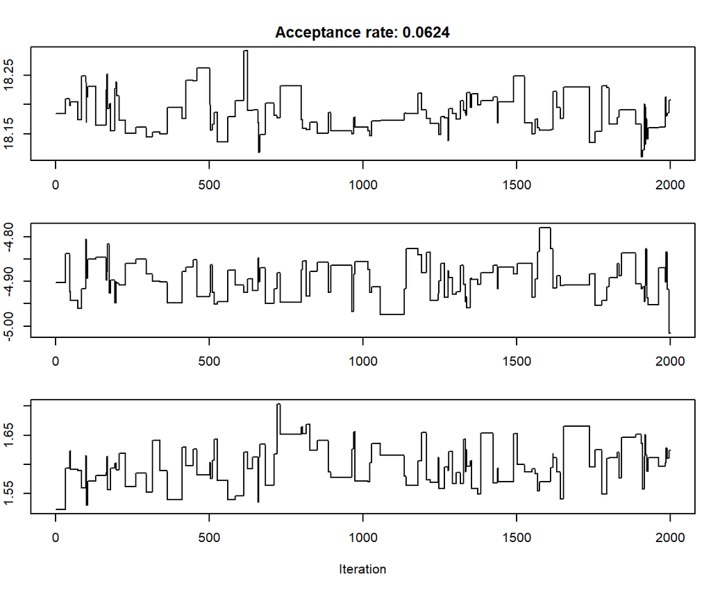

## Still better mixing:

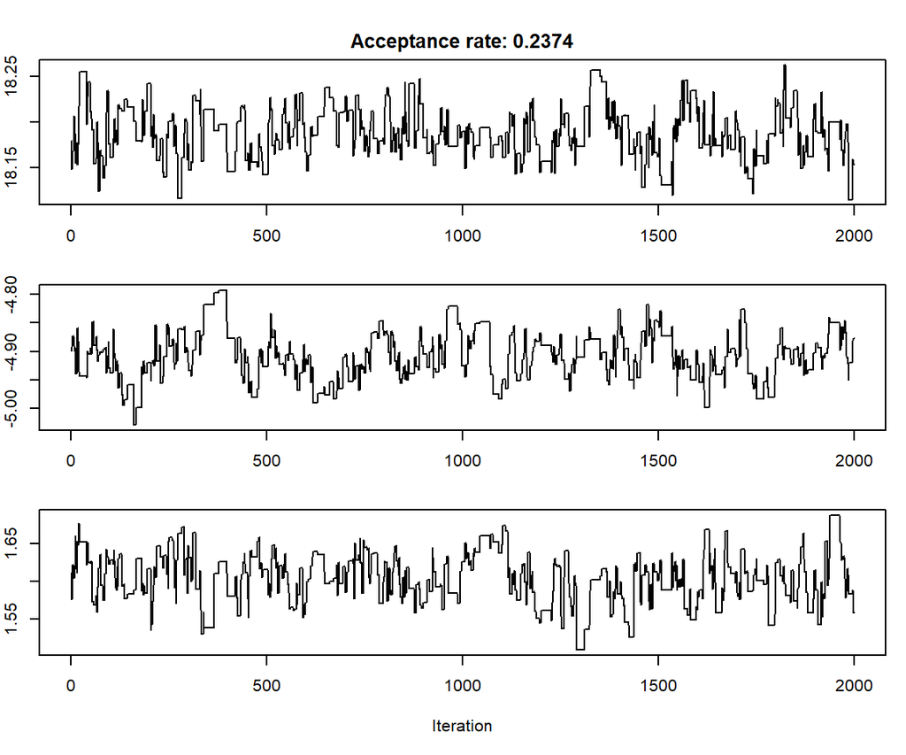

## Little mixing (too high acceptance rate: too much autocorrelation)

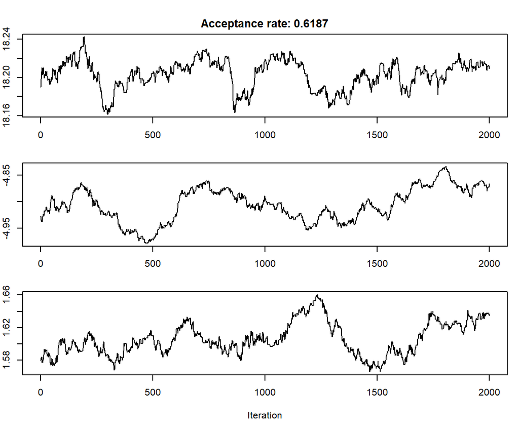

## Burn-in

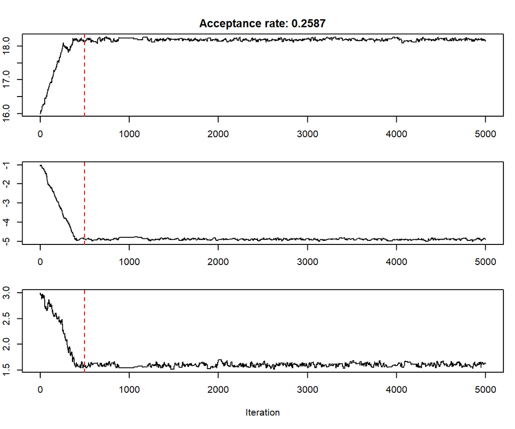

## The sample distribution

We can interpret the results as a sample of the parameter’s probability density and use results to compute point estimates and to quantify uncertainties in parameter estimation.

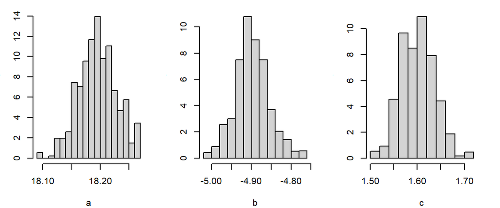

## How do we derive $P(\theta_t)$ and $P(\theta')$

How do we decide whether $\theta'$ is a reasonable alternative?

Idea: We take its *likelihood* i.e. the probability of the data given the parameters.

$$P(y_i | \theta) = \frac{1}{\sigma \sqrt{2 \pi}} e^{-\frac{\left( y_i - f_{\theta}(x_i) \right)^2}{2 \sigma^2}}$$

where $y_i - f_{\theta}(x_i) = 0$ has the largest probability, i.e. the maximum likelihood for $\theta$.

## How do we derive $P(\theta_t)$ and $P(\theta')$

With the independence we can build the likelihood function for $\theta$ given all measurements:

$$\begin{aligned}
L(\theta) = P(y | \theta) &= \prod_{i=1}^{n}\frac{1}{\sigma \sqrt{2 \pi}} e^{-\frac{\left( y_i - f_{\theta}(x_i) \right)^2}{2 \sigma^2}} \\
&= \left(\frac{1}{\sigma \sqrt{2 \pi}} \right)^n \cdot \prod_{i=1}^{n} e^{-\frac{\left( y_i - f_{\theta}(x_i) \right)^2}{2 \sigma^2}} \\
&= \left(\frac{1}{\sigma \sqrt{2 \pi}} \right)^n \cdot e^{-\frac{ \sum_{i=1}^{n} \left( y_i - f_{\theta}(x_i) \right)^2 }{2 \sigma^2}}
\end{aligned}$$

## How do we derive $P(\theta_t)$ and $P(\theta')$

Now we can plug in the sum of quared errors

$$P(y | \theta) = \left(\frac{1}{\sigma \sqrt{2 \pi}} \right)^n e^{-\frac{ \textrm{SSE}_{\theta} }{2 \sigma^2}}$$

and can estimate $\sigma^2$ from the data:

$$\sigma^2 = \frac{1}{n} \sum_{i=1}^{n} (y_i - f(x_i))^2 = \frac{\textrm{SSE}_{\theta}}{n}$$

(see implementation of the Metropolis algorithm in the lab)

## How do we derive $P(\theta_t)$ and $P(\theta')$

In Metropolis iterations, we need the ratio $\frac{P(\theta')}{P(\theta_t)}$. This reduces to:

$$\begin{aligned}
\frac{P(\theta')}{P(\theta_t)} &= \frac{\left(\frac{1}{\sigma \sqrt{2 \pi}}\right)^n \cdot e^{-\frac{ \textrm{SSE}' }{2 \sigma^2}}}{\left(\frac{1}{\sigma \sqrt{2 \pi}}\right)^n \cdot e^{-\frac{ \textrm{SSE}_t }{2 \sigma^2}}} \\
&= \frac{e^{-\frac{ \textrm{SSE}' }{2 \sigma^2}}}{e^{-\frac{ \textrm{SSE}_t' }{2 \sigma^2}}} \\
&= e^{-\frac{ \textrm{SSE}' }{2 \sigma^2} + \frac{ \textrm{SSE}_t }{2 \sigma^2} } \\
&= e^{\frac{\textrm{SSE}_t - \textrm{SSE}' }{2 \sigma^2} }
\end{aligned}$$

## Metropolis algorithm

**Probability of accepting a random proposal:**

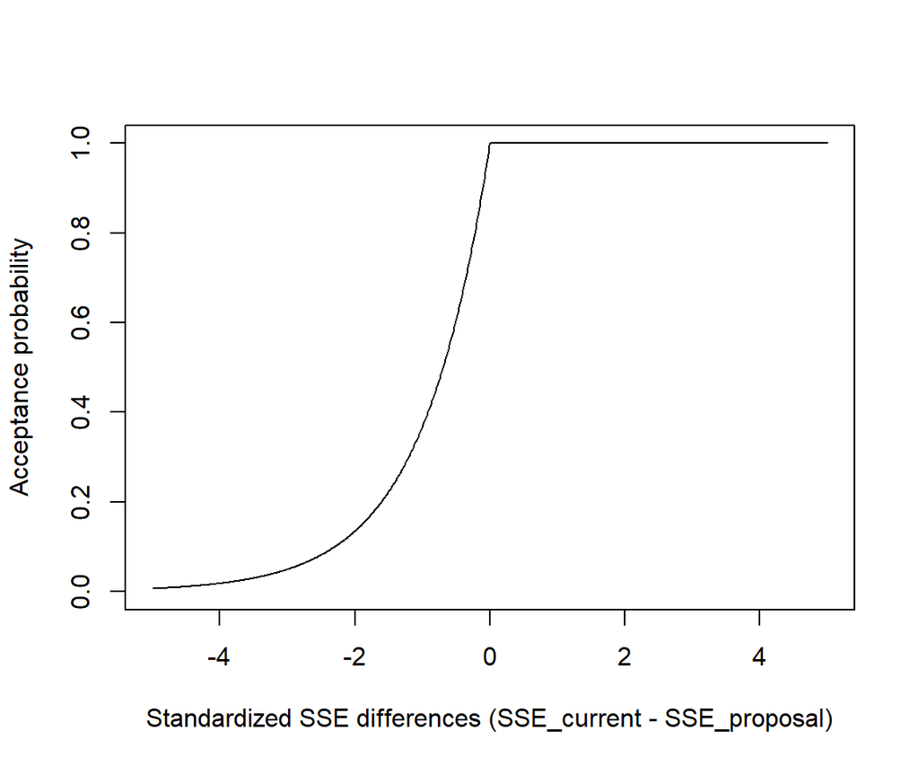

## Likelihood ratio – side track

For evaluating acceptance, the ratio $\frac{P(x')}{P(x_t)}$ is needed, not the individual values.

This means that $P(x')$ and $P(x_t)$ are only needed *up to a normalizing constant*: if we have values $aP(x')$ and $aP(x_t)$, than that is sufficient as $a$ cancels out.

This result is *key* to the reason that MCMC and M-H are the work horse in Bayesian statistics, where $P(x')$ is extremely hard to find because it calls for the evaluation of a very high-dimensional integral (the normalizing constant that makes sure that $P(\cdot)$ is a probability) but $aP(x')$, the likelihood of $x$ given data, is much easier to find!

## Simulated annealing

Simulated Annealing is a related global search algorithm, does not sample the full parameter distribution but searches for the (global) optimimum.

The analogy with *annealing*, the forming of crystals in a slowly cooling substance, is the following:

The current solution is replaced by a worse “nearby” solution with a certain probability that depends on the the degree to which the “nearby” solution is worse, and on the temperature of the cooling process; this temperature slowly decreases, allowing less and smaller changes.

## Simulated annealing

At the start, temperature is large and search is close to random; when temperature decreases search is more and more local and downhill. Random, uphill jumps prevent SA to fall into a local minimum.

A related algorithm (stochastic optimization) is the Genetic Algorithm.

## Non-linear optimization methods by example

**Example:** Temperature time series with given mean

Our model is
$$18.12634 + b_1 \sin \left( \pi (x_i + b_2) / 12 \right)$$

and our parameter vector is $\theta = (b_1,b_2)$ whose elements represent the amplitude and phase respectively.

## Non-linear optimization methods by example

**The dataset:**

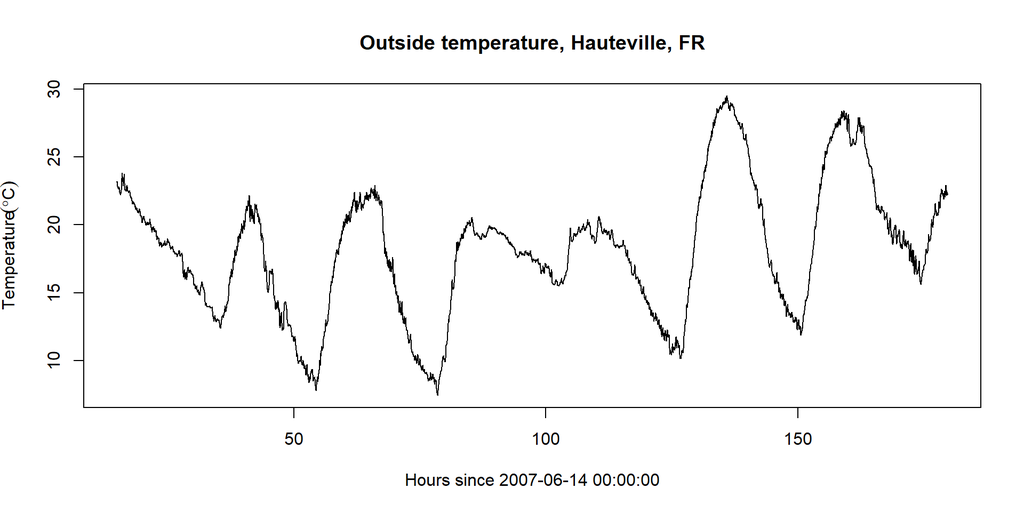

$x = (14.91667, 14.93333, 14.95, 14.96667, ...)^T$ $y = (23.20, 23.17, 23.14, 23.09, ...)^T$

## Non-linear optimization methods by example

Assuming the sum of squared errors as optimization criteria, how does the objective function look like?

## The objective function

$\textrm{SSE}(b_1,b_2) = \sum_{i=1}^{n} \left(y_i - \left(18.12634 + b_1 \sin \left( \pi (x_i + b_2) / 12 \right) \right) \right)^{2}$

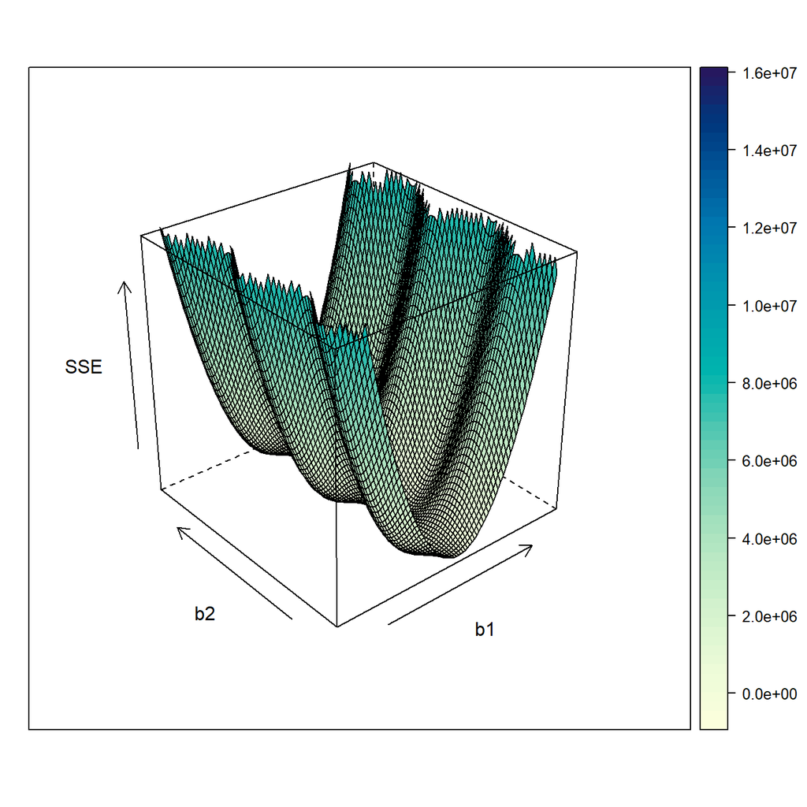

## Non-linear optimization methods by example

Let’s try different optimization algorithms to find optimal values. We use the (poor) starting values $b_1=30$, $b_2=4$ which yield 5770875 as the sum of squared differences.

## Non-linear optimization methods by example

**Gauss Newton**:

| Iteration | b1 | b2 | SSE |
| --- | --- | --- | --- |
| 1 | 30 | 4 | 5770875 |
| 2 | -3.969002 | 4.366534 | 162366.7 |
| 3 | -3.674925 | 1.242831 | 117179 |
| 4 | -4.881289 | 1.722770 | 109114.6 |
| 5 | -4.900673 | 1.602571 | 108995.6 |
| 6 | -4.903080 | 1.603086 | 108995.5 |

## Non-linear optimization methods by example

**Metropolis**:

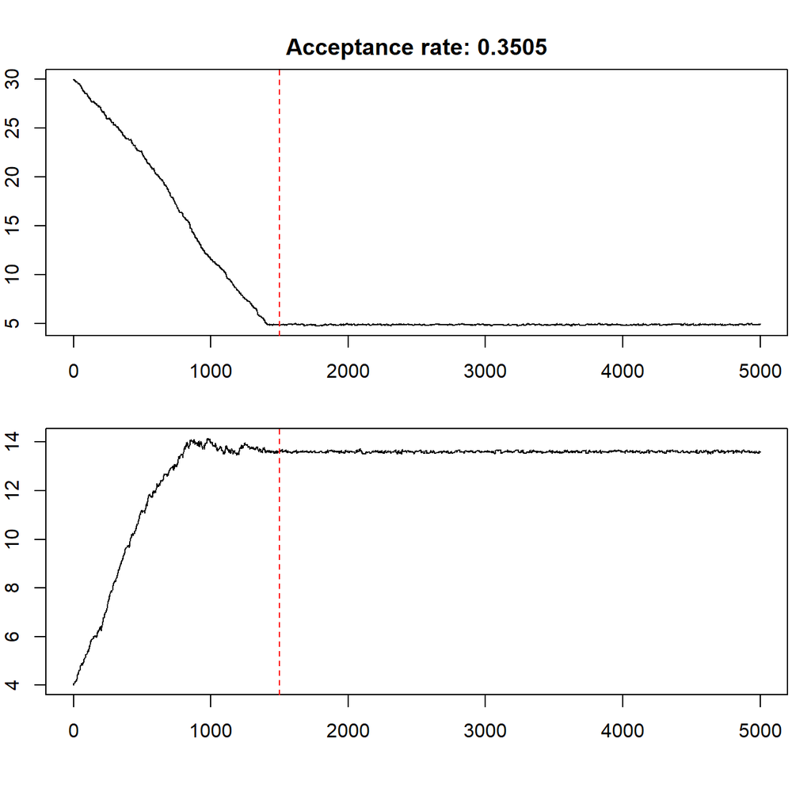

## Non-linear optimization methods by example

Metropolis point estimations could be $b_1 = 4.8969604$ and $b_2 =13.6046841$ where the sum of squared errors is 108995.8.

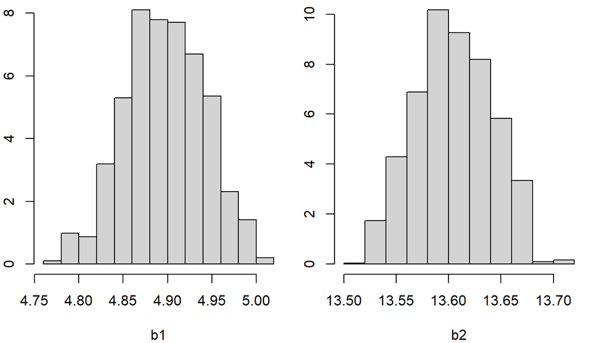

## Non-linear optimization methods by example

**Simulated annealing**:

After 10000 iterations, simulated annealing returns point estimates $b_1=4.9027349$ and $b_2=13.6033015$ with 108995.5 as the sum of squared differences.

## Optimization summary

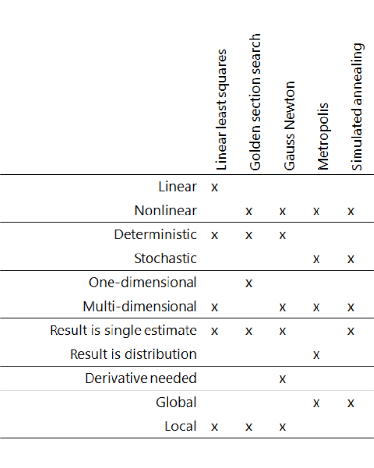

## Notes

- Do the practical excercises to understand the details of optimization!
- Read the tutorial document (German) which we provide at Learnweb
- Next: Spatial models, spatial interpolation, spatial dependencies.